# 00 Introducción

2024-01-15

## Bienvenidos al curso de Análisis de datos I (MAT1409)

## Bienvenidos al curso de Análisis de datos I (MAT1409)

- Bienvenida Presentación.
- Brightspace
- Curso (Planeación Docente)

## Políticas del Curso

## Políticas del Curso

**Puntualidad:** Es importante llegar a tiempo a las clases y cumplir con los horarios establecidos (tolerancia de 15 minutos).

**Asistencia:** Los alumnos deben asistir a todas las clases programadas y notificar al director y al maestro en caso de no poder asistir debido a una emergencia o enfermedad (Cumplir con el requisito de 80% de asistencia).

**Participación activa**: Los alumnos deben participar activamente en las clases, lo que incluye hacer preguntas, participar en discusiones y completar todas las tareas asignadas.

## Políticas del Curso

**Respeto a los demás**: Los alumnos deben respetar a sus compañeros de clase y a sus profesores, y no deben interrumpir a los demás cuando están hablando.

**Honestidad académica** : Los alumnos deben evitar el plagio y otras formas de deshonestidad académica.

**Comportamiento adecuado** : Los alumnos deben comportarse de manera adecuada en clase, lo que incluye evitar el uso de lenguaje ofensivo y mantener un ambiente de aprendizaje positivo.

## Políticas del Curso

**Uso de dispositivos electrónicos**: Los alumnos deben usar los dispositivos electrónicos de manera responsable durante las clases.

**Cumplimiento de las tareas** : Los alumnos deben completar todas las tareas asignadas a tiempo.

**Ordinario** : Es obligatoria la asistencia al examen ordinario.

**Calculadora**:Para el curso vamos a requerir una calculadora científica sencilla.

## Evaluación

## Evaluación

- Examen escrito 1 Parcial = M 30.00
- Examen escrito 2 Parcial = M 30.00
- Examen escrito final 1 Final = F 40.00
- Requisito de asistencia mínima.
- Requisito de asistencia a evaluación final.
- **Tareas, ejercicios y trabajos en equipo (40% del parcial)**

## Parciales y Ordinario

## Parciales y Ordinario

- **Primer parcial**: 13 sesiones.  
  Evaluar: [Temas: 1-3] Introducción a la estadística descriptiva y representación gráfica..  
  Fecha: Jueves 29 febrero.
- **Segundo parcial**: 11 sesiones.  
  Evaluar: [Temas: 4-5] Introducción a la probabilidida y distribuciones estadísticas.  
  Fecha: Jueves 9 de mayo.
- **Exámen ordinario**: (13-21) de mayo.  
  Evaluar: [Temas: 1-5]

**Las fechas establecidas podrían experimentar modificaciones a lo largo del desarrollo del curso.**

## Resultados del Aprendizaje

## Resultados del Aprendizaje

Al finalizar el curso, el alumno podrá estimar de forma precisa parámetros para hacer inferencias correctas y mejorar la toma de decisiones en la economía y los negocios.

## Curso

## Curso

1. Introducción a la estadística y análisis de datos.
2. Estadística descriptiva.
3. Representación tabular y gráfica de la información.
4. Introducción a la Probabilidad.
5. Distribuciones de probabilidad.

## Tema 1: Introducción a la estadística y análisis de datos.

## Tema 1: Introducción a la estadística y análisis de datos.

- Ramas de la Estadística.
  - Frecuentista.
  - Bayesiana.
- Población, Muestra, Parámetros y Estimadores.
- Tipos de variables y Escalas.
- Estructura de los datos.

## Tema 1: Introducción a la estadística y análisis de datos.

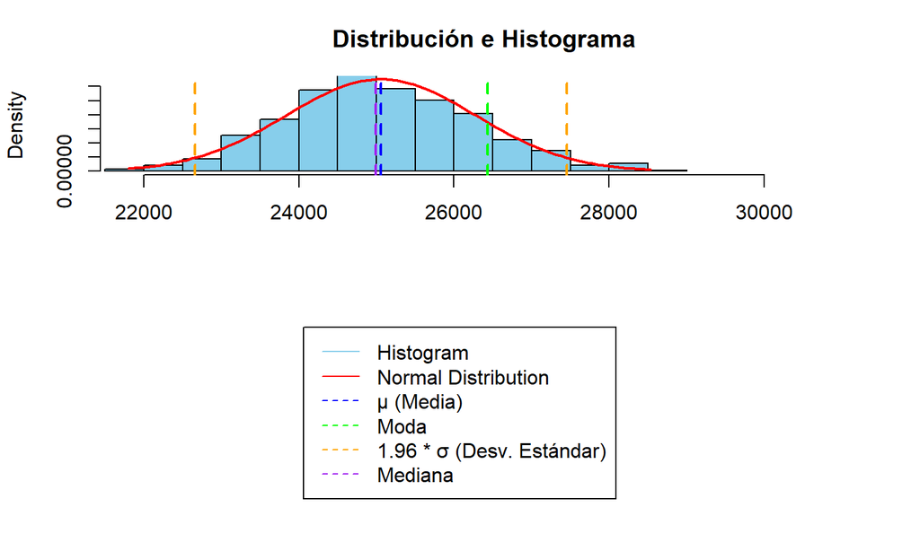

## Tema 1: Introducción a la estadística y análisis de datos.

- Tipos de variables

[interactive chart not shown]

## Tema 1: Introducción a la estadística y análisis de datos.

- Tipos de Datos: Cross-Section, una unidad de análisis

| ID | Variable1 | Variable2 | Variable3 | Variable4 | Variable5 |
| --- | --- | --- | --- | --- | --- |
| 1 | -0.9284635 | 0.8234590 | b | 88 | 1 |
| 2 | 1.4680517 | 0.6215567 | c | 87 | 1 |
| 3 | 0.2507076 | 0.2725985 | a | 30 | 1 |
| 4 | -0.4705852 | 0.1093889 | b | 86 | 1 |

## Tema 1: Introducción a la estadística y análisis de datos.

- Tipos de Datos: Time-series, una unidad de análisis a traves del tiempo.

| ID | Variable1 | Variable2 | Variable3 | Variable4 | Variable5 |
| --- | --- | --- | --- | --- | --- |
| 1 | -0.5654730 | 0.1379444 | b | 88 | 1 |
| 2 | -1.0701583 | 0.6594631 | c | 10 | 1 |
| 3 | 2.0353788 | 0.3320986 | a | 56 | 1 |
| 4 | 0.9187915 | 0.4287615 | b | 100 | 0 |

## Tema 1: Introducción a la estadística y análisis de datos.

- Tipos de Datos: Panel, varias unidaded de análisis a traves del tiempo.

| ID | Time | Variable1 | Variable2 | Variable3 | Variable4 | Variable5 |
| --- | --- | --- | --- | --- | --- | --- |
| 1 | 1 | -0.5604756 | 0.8895393 | a | 7 | 0 |
| 1 | 2 | -0.2301775 | 0.6928034 | b | 9 | 1 |
| 2 | 1 | 1.5587083 | 0.6405068 | c | 41 | 1 |
| 2 | 2 | 0.0705084 | 0.9942698 | b | 74 | 0 |

## Tema 1: Introducción a la estadística y análisis de datos.

- Scales

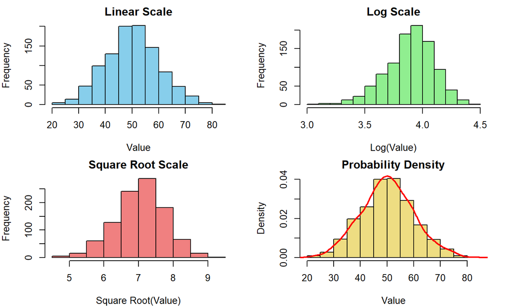

## Tema 2: Estadísticos descriptivos

## Tema 2: Estadísticos descriptivos

- Medidas de tendencia Central

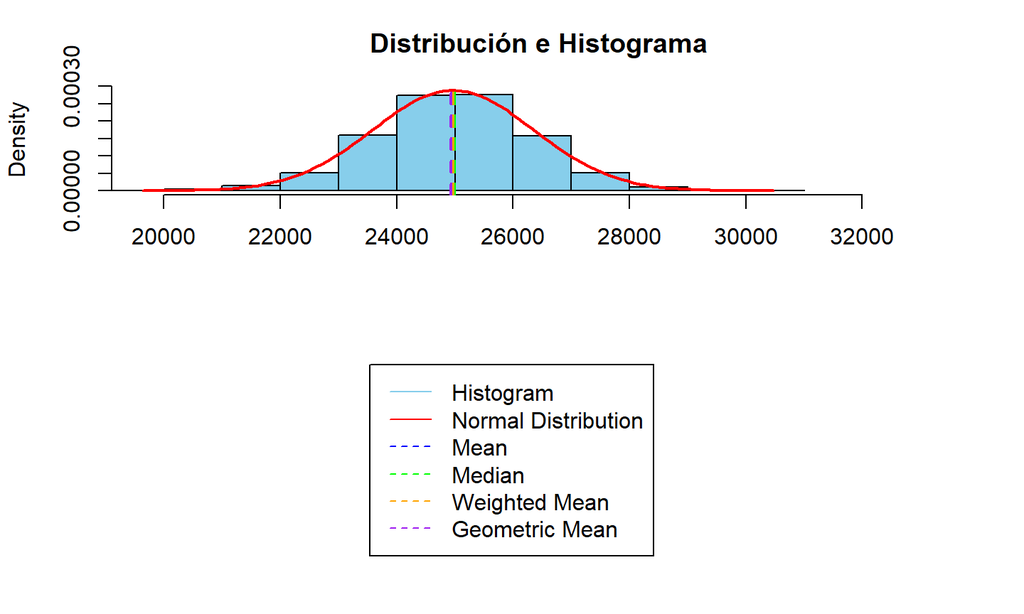

## Tema 2: Estadísticos descriptivos

- Medidas de tendencia Central: Mean and Median

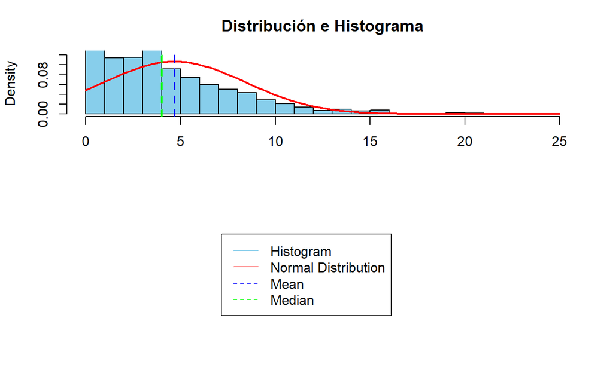

## Tema 2: Estadísticos descriptivos

- Medidas de tendencia Central: Mean and Armonic Mean

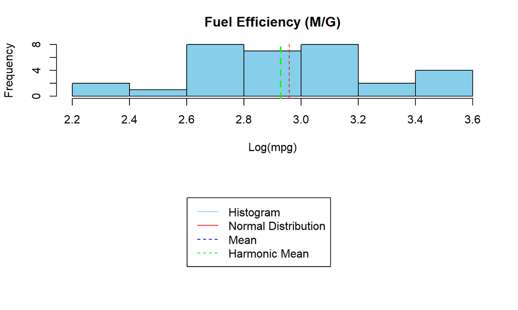

## Tema 3: Representación tabular y gráfica de la información

## Tema 3: Representación tabular y gráfica de la información

- Tablas de Frecuencia, continous variable

| Frecuencia | Intervalo |
| --- | --- |
| 94 | [0 - 500] |
| 44 | [500 - 1000] |
| 37 | [1000 - 1500] |
| 30 | [1500 - 2000] |
| 30 | [2000 - 2500] |

## Tema 3: Representación tabular y gráfica de la información

[figure not shown]

[output not shown]

## 4 Introducción a la Probabilidad

## 4 Introducción a la Probabilidad

Venn diagram

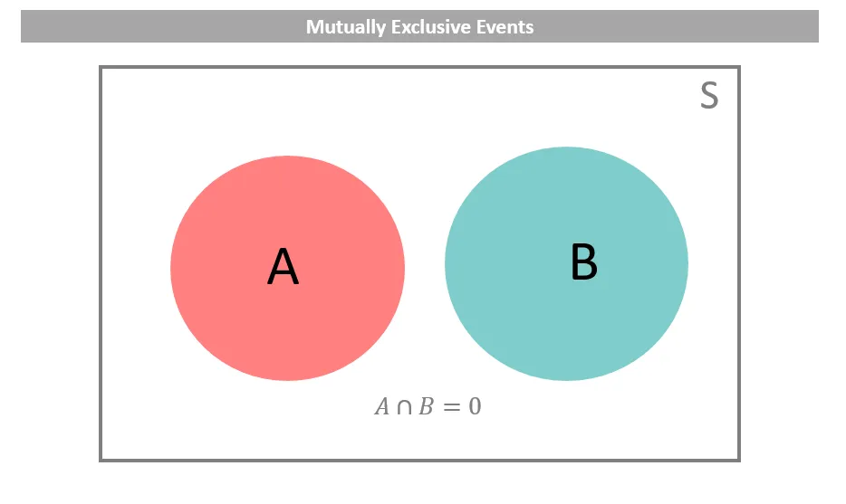

## 4 Introducción a la Probabilidad

Eventos Independientes

A and B. Let \(P(A) = 0.6\) and \(P(B) = 0.4\). Then \(P(A \cup B)\) is given by:

\[P(A) = 0.6\] \[P(B) = 0.4\] \[P(A \cap B) = P(A) \cdot P(B) = 0.6 \cdot 0.4 = 0.24\]

\[P(A \cup B) = P(A) + P(B) - P(A \cap B) = 0.6 + 0.4 - 0.24\]

Hence, \(P(A \cup B)\) is 76%.

## 4 Introducción a la Probabilidad

Bayes Rule

Dia en la Playa:

Donde: - \(P(Lluvia)\) es la Probabilidad de Lluvia = 10%  
- \(P(Nublado|Lluvia)\) es la Probabilidad de Nublado dado que ocurre Lluvia = 50%  
- \(P(Nublado)\) es la Probabilidad de Nublado = 40%

## 4 Introducción a la Probabilidad

Bayes Rule

Segun Bayes:

\[ P(Lluvia|Nublado) = \frac{P(Lluvia) \cdot P(Nublado|Lluvia)}{P(Nublado)} \]

Sustituyendo los valores: \[ P(Lluvia|Nublado) = \frac{0.1 \cdot 0.5}{0.4} = 0.125 \]

Mejor si vamos!

## 5 Distribuciones de probabilidad

## 5 Distribuciones de probabilidad

- Binomial, lazar una moneda:
- Número total de lanzamientos: \(n = 10\)
- Número de caras deseadas \(k = 3\)
- Probabilidad de cara en un solo lanzamiento: \(p = 0.5\)

\[ P(k \text{ out of } n) = \frac{{n!}}{{k!(n-k)!}} p^k (1-p)^{n-k} \]

Sustituyendo con los valores dados:

\[ P(3 \text{ out of } 10) = \frac{{10!}}{{3!(10-3)!}} (0.5)^3 (1-0.5)^{10-3} \]

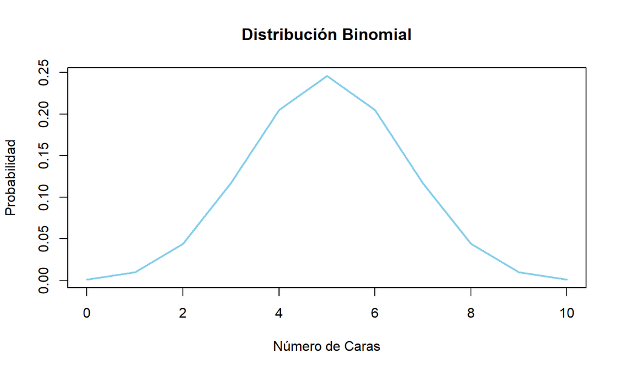

## 5 Distribuciones de probabilidad

- Poisson, number of events occurring in a given time period. \[ P(X = k) = \frac{e^{-\lambda} \lambda^k}{k!} \]
- En un partido de football, se meten en promedio 2.5 goles
- ¿Cuál es la prob. de que se metan 4?

\[ P(X = 4) = \frac{e^{-2.5} \cdot 2.5^4}{4!}=0.13 \]

## 5 Distribuciones de probabilidad

[figure not shown]

## Bibliografía

## Bibliografía

- Smith, G. (2015). *Essential statistics, regression, and econometrics.*